# 問1

## 関数の実装

まず,2つの関数とその微分を実装しておく.

(i)の目的関数を$f_1(\boldsymbol{x})$, (ii)の目的関数を$f_2(\boldsymbol{x})$とする.

```python
import pandas as pd
import matplotlib.pyplot as plt
from mpl_toolkits.mplot3d import Axes3D
import math
import numpy as np
from numpy import linalg as LA
import copy
from copy import deepcopy
```

```python
def f1(vec_x):
    x, y = vec_x[0], vec_x[1]
    return x**2 + y**2 + math.exp(- x**2 - y**2)

def nabla_f1(vec_x):
    x, y = vec_x[0], vec_x[1]
    res_x = 2 * x * (1 - math.exp(- x**2 - y**2))
    res_y = 2 * y * (1 - math.exp(- x**2 - y**2))
    return np.array([res_x, res_y])

def nabla2_f1(vec_x):
    x, y = vec_x[0], vec_x[1]
    return np.array([[(4 * x**2-2) * math.exp(-x**2-y**2) + 2, 4 * x * y * math.exp(-x**2-y**2)],\
                     [4 * x * y * math.exp(-x**2-y**2), (4 * y**2-2) * math.exp(-x**2-y**2) + 2]])
```

```python
def f2(vec_x):
    x, y = vec_x[0], vec_x[1]
    return 2 * x**2 - 1.05 * x**4 + x**6 / 6 + x*y + y**2

def nabla_f2(vec_x):
    x, y = vec_x[0], vec_x[1]
    res_x = 4 * x - 4.2 * x**3 + x **5 + y
    res_y = x + 2 * y
    return np.array([res_x, res_y])

def nabla2_f2(vec_x):
    x, y = vec_x[0], vec_x[1]
    return np.array([[4-12.6*x**2+5*x**4, 1],\
                     [1, 2]])
```

## 関数の観察

```python
# 目的関数をプロットする関数
def plot3D(f, x_min=-5, x_max=5, x_num=101, y_min=-5, y_max=5, y_num=101):
    fig = plt.figure(figsize=(16,5))
    ax1 = fig.add_subplot(1,2,1, projection='3d')
    ax2 = fig.add_subplot(1,2,2)

    x = np.linspace(x_min, x_max, x_num)
    y = np.linspace(y_min, y_max, y_num)

    X, Y = np.meshgrid(x, y)
    Z = np.array([[f([x_e, y_e]) for x_e in x] for y_e in y])

    ax1.set_xlabel('$x$')
    ax1.set_ylabel('$y$')
    ax1.plot_surface(X,Y,Z, cmap='terrain')

    ax2.set_xlabel('$x$')
    ax2.set_ylabel('$y$')
    mesh = ax2.pcolormesh(X, Y, Z, shading='auto')
    cbar = fig.colorbar(mesh)
    cbar.set_label('$z$')

    plt.show()
```

### (i) $f_1$の観察

1階微分は,

$$\nabla f_1(\boldsymbol{x}) = \left(\begin{matrix} 2x(1-\text{exp}(-x^2-y^2) \\ 2y(1-\text{exp} (-x^2-y^2)) \end{matrix}\right)$$

また2階微分は,

$$\nabla ^2 f_1(\boldsymbol{x}) = \left( \begin{matrix} (4x^2-2)\text{exp}(-x^2-y^2)+2 & 4xy\text{exp}(-x^2-y^2) \\ 4xy\text{exp}(-x^2-y^2) & (4y^2-2)\text{exp}(-x^2-y^2)+2 \end{matrix}\right)$$

である. これが半正定値であることを示す.

まず, $(1,1)$成分は,$4x^2\text{exp}(-x^2-y^2) +2(1-\text{exp}(-x^2-y^2))$ と変形でき, $\text{exp}(-x^2-y^2)$が$1$以下であることに注意すると, これは非負とわかる.同様にして$(2,2)$成分も非負である.

続いて, $\text{det}\nabla^2 f_1(\boldsymbol{x})$ を計算する. 以下では $A:=\text{exp}(-x^2-y^2)$ と置換している.

$$ \begin{align} \text{det}\nabla^2 f_1(\boldsymbol{x}) &= \left\{2(1-A) + 4x^2A\right\}\left\{2(1-A) + 4y^2A\right\} - (4xyA)^2 \\&= 4(1-A)^2 + 8(x^2+y^2)(1-A)A \end{align} $$

$A \geq 0$に注意すると, これは非負である.

よって, $\nabla^2 f_1(\boldsymbol{x})$ は全ての小行列の行列式が非負なので,半正定値である.

これより,講義内で示された定理から, $f_1(\boldsymbol{x})$が凸であることが従う.

従って,大域的最適解が存在し,バックトラキング法を用いるとその値に収束する.

ここで,$\nabla f_1(\boldsymbol{x}) = \boldsymbol{0}$ を解析的に解くと, $\left(\begin{matrix} 0 \\ 0 \end{matrix}\right)$ であるから,大域的最適解は原点である.

以上の考察を図示して確認する.

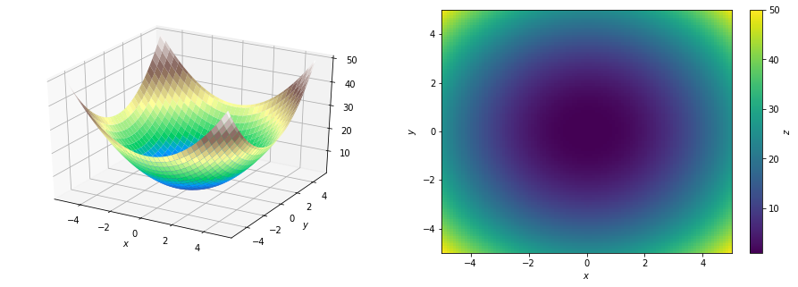

```python
plot3D(f1)
```

### (ii) $f_2$の観察

1階微分を計算する. $$\nabla f_2(\boldsymbol{x}) = \left(\begin{matrix} 4x - 4.2x^3 + x^5 + y \\ x+2y \end{matrix}\right)$$

2階微分を計算する.

$$ \begin{align} \nabla ^2 f_2(\boldsymbol{x}) &= \left(\begin{matrix} 4 - 12.6x^2 + 5x^4 & 1 \\ 1 & 2\end{matrix} \right) \end{align} $$

実際,$\nabla f_2(\boldsymbol{x}) = \boldsymbol{0}$ をWolframAlphaで解くと,

$$\boldsymbol{x} \simeq \left(\begin{matrix} 0 \\ 0 \end{matrix}\right), \pm \left(\begin{matrix} 1.74755 \\ -0.87377 \end{matrix}\right), \pm \left(\begin{matrix} 1.07054 \\ -0.53527 \end{matrix}\right)$$

という$5$つの停留点が存在し,このそれぞれについて$f_2(\boldsymbol{x})$のおよその値は,$0, 0.2986, 0.87736$である.

さて,これらの停留点が極大点・極小点・鞍点のいずれであるかを判別しておく. $\nabla f_2(\boldsymbol{x})$の固有値 $\lambda$の符号を調べれば良い.

固有多項式は, $\lambda^2 - (6-12.6x^2+5x^4) \lambda + (7-25.2x^2+10x^4)=0$ より, $x=0, \pm 1.74755, \pm1.07054$のそれぞれについて $\lambda$ を求めると,

$x=0$ では, $\lambda \simeq 1.58579, 4.41421$ で, ともに正. すなわち$\left(\begin{matrix} 0 \\ 0 \end{matrix}\right)$では極小点

$x=\pm 1.74755$ では, $\lambda \simeq 1.90253, 12.2504$ で, ともに正. すなわち$\pm \left(\begin{matrix} 1.74755 \\ -0.87377 \end{matrix}\right)$付近の停留点は極小点

$x=\pm 1.07054$ では, $\lambda \simeq -4.0368, 2.1656$ で, 異符号. すなわち$\pm \left(\begin{matrix} 1.07054 \\ -0.53527 \end{matrix}\right)$付近の停留点は鞍点

であると考えられる. また,この計算結果より原点が大域的最適解であると考えられる.

従って,初期値次第では最急降下法やNewton法では大域的最適解(原点)に収束しないことが予想される.

以上の考察を図示して確認する.

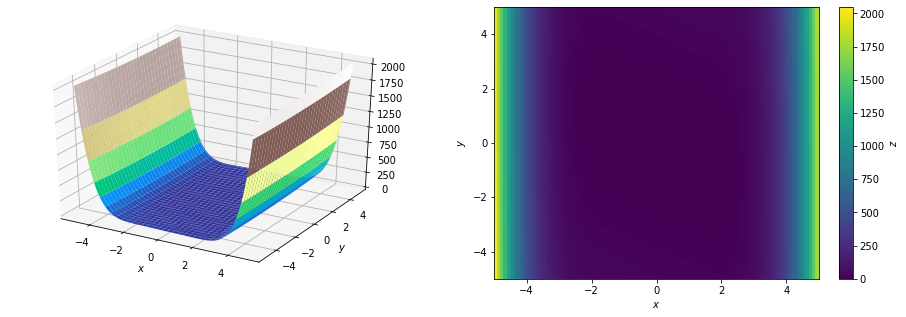

```python
plot3D(f2)
```

#### $x=0$ 付近を拡大

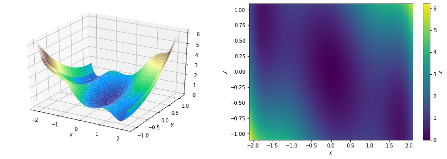

```python
plot3D(f2, x_min=-2.1, x_max=2.1, y_min=-1.1, y_max=1.1)
```

## 手法の実装

### バックトラッキング法を用いた最急降下法の実装

関数 `BackingTrackingMethod` を実装した.

引数は目的関数$f$(`f`) (および$\nabla f$(`nabla_f`)), 初期値$x_0$(`x_in`), 許容誤差$\epsilon $(`eps`), アルミホ条件に用いるパラメータ $c_1$(`c_1`), $\alpha_0$(`alpha_0`)および$\rho$(`rho`), 計算回数`max_times` である.

```python
def BacktrackingMethod(f, nabla_f, x_in, eps=0.000001, c_1=0.8, alpha_0=10, rho=0.8, max_times=10000):
    log_df = pd.DataFrame(columns=['x_k', 'd_k', 'output', 'alpha'])

    tmp_x = x_in
    tmp_alpha = alpha_0

    def armijo_condition(x, d, alpha):
        return f(x + alpha * d) <= f(x) + c_1 * alpha * np.dot(nabla_f(x), d)

    while True :
        tmp_nabla = nabla_f(tmp_x)
        # 最大でmax_times回繰り返す, |nabla_f(x)| < epsになったら打ち切り
        if len(log_df) == max_times or LA.norm(tmp_nabla) < eps : break
        d = - tmp_nabla      # 降下方向
        while not armijo_condition(tmp_x, d, tmp_alpha):
            tmp_alpha *= rho
        log_df = log_df.append({'x_k':deepcopy(tmp_x), 'd_k':d, 'output':f(tmp_x), 'alpha':tmp_alpha}, ignore_index=True)
        tmp_x += tmp_alpha * d

    res_x = tmp_x
    return log_df, res_x
```

### ニュートン法の実装

関数`NewtonsMethod`を実装した.

引数は目的関数$f$(`f`) (および$\nabla f$(`nabla_f`), $\nabla^2 f$(`nabla2_f`)), 初期値$x_0$(`x_in`), 許容誤差$\epsilon $(`eps`), 計算回数`max_times` である.

```python
def NewtonsMethod(f, nabla_f, nabla2_f, x_in, eps=0.000001, max_times=10000):
    log_df = pd.DataFrame(columns=['x_k', 'd_k', 'output'])

    tmp_x = x_in
    while True:
        tmp_nabla = nabla_f(tmp_x)
        # 最大でmax_times回繰り返す, |nabla_f(x)| < epsになったら打ち切り
        if len(log_df) == max_times or LA.norm(tmp_nabla) < eps : break
        d = - np.dot(LA.inv(nabla2_f(tmp_x)), nabla_f(tmp_x))      # 降下方向
        log_df = log_df.append({'x_k':deepcopy(tmp_x), 'd_k':d, 'output':f(tmp_x)}, ignore_index=True)
        tmp_x += d

    res_x = tmp_x
    return log_df, res_x
```

## 最小化

### $f_1$ の最小化

#### 初期値 $(-1,-1)^\text{T}$, 最急降下法

```python
log_f1_1_back, res_f1_1_back = BacktrackingMethod(f1, nabla_f1, [-1,-1])
```

```python
log_f1_1_back
```

|  | x_k | d_k | output | alpha |
| --- | --- | --- | --- | --- |
| 0 | [-1, -1] | [1.7293294335267746, 1.7293294335267746] | 2.135335 | 0.115292 |
| 1 | [-0.8006218907537402, -0.8006218907537402] | [1.1569237272058395, 1.1569237272058395] | 1.559475 | 0.115292 |
| 2 | [-0.6672376663251883, -0.6672376663251883] | [0.7866912072369789, 0.7866912072369789] | 1.300899 | 0.115292 |
| 3 | [-0.5765383452943248, -0.5765383452943248] | [0.5599570669712278, 0.5599570669712278] | 1.179173 | 0.115292 |
| 4 | [-0.5119796908775542, -0.5119796908775542] | [0.41777407211145834, 0.41777407211145834] | 1.116248 | 0.115292 |
| ... | ... | ... | ... | ... |
| 9995 | [-0.010416476544768589, -0.010416476544768589] | [4.520384642188564e-06, 4.520384642188564e-06] | 1.000000 | 0.115292 |
| 9996 | [-0.01041595537990228, -0.01041595537990228] | [4.519706223511277e-06, 4.519706223511277e-06] | 1.000000 | 0.115292 |
| 9997 | [-0.010415434293252321, -0.010415434293252321] | [4.519027974509089e-06, 4.519027974509089e-06] | 1.000000 | 0.115292 |
| 9998 | [-0.010414913284799147, -0.010414913284799147] | [4.518349895124307e-06, 4.518349895124307e-06] | 1.000000 | 0.115292 |
| 9999 | [-0.010414392354523204, -0.010414392354523204] | [4.517671985296944e-06, 4.517671985296944e-06] | 1.000000 | 0.115292 |

10000 rows × 4 columns

$(x,y)\simeq(-0.010414, -0.010414)$で打ち切られ,そこでの$f_1$の値は$1.00000$である.

先に解析的に求めた大域的最適解に近い値となっている.

#### 初期値 $(2,-1)^\text{T}$, 最急降下法

```python
log_f1_2_back, res_f1_2_back = BacktrackingMethod(f1, nabla_f1, [2,-1])
```

```python
log_f1_2_back
```

|  | x_k | d_k | output | alpha |
| --- | --- | --- | --- | --- |
| 0 | [2, -1] | [-3.973048212003658, 1.986524106001829] | 5.006738 | 0.144115 |
| 1 | [1.4274234096926492, -0.7137117048463246] | [-2.631248443220448, 1.315624221610224] | 2.625244 | 0.144115 |
| 2 | [1.048220545423631, -0.5241102727118155] | [-1.5655597261681151, 0.7827798630840576] | 1.626688 | 0.115292 |
| 3 | [0.8677237979190682, -0.4338618989595341] | [-1.058333423929638, 0.529166711964819] | 1.331348 | 0.115292 |
| 4 | [0.7457062615698006, -0.3728531307849003] | [-0.7471590501632852, 0.3735795250816426] | 1.194123 | 0.115292 |
| ... | ... | ... | ... | ... |
| 9995 | [0.0131766859913031, -0.00658834299565155] | [-5.718886421338536e-06, 2.859443210669268e-06] | 1.000000 | 0.115292 |
| 9996 | [0.013176026648589344, -0.006588013324294672] | [-5.7180280314467115e-06, 2.8590140157233557e-06] | 1.000000 | 0.115292 |
| 9997 | [0.013175367404841204, -0.006587683702420602] | [-5.717169856267392e-06, 2.858584928133696e-06] | 1.000000 | 0.115292 |
| 9998 | [0.013174708260033927, -0.0065873541300169635] | [-5.716311895724656e-06, 2.858155947862328e-06] | 1.000000 | 0.115292 |
| 9999 | [0.013174049214142764, -0.006587024607071382] | [-5.715454149745522e-06, 2.857727074872761e-06] | 1.000000 | 0.115292 |

10000 rows × 4 columns

$(x,y)\simeq(0.013173, -0.006587)$で打ち切られ,そこでの$f_1$の値は$1.00000$である.

先に解析的に求めた大域的最適解に近い値となっている.

#### 初期値 $(-1,-1)^\text{T}$, ニュートン法

```python
log_f1_1_newton, res_f1_1_newton = NewtonsMethod(f1, nabla_f1, nabla2_f1, [-1,-1])
```

```python
log_f1_1_newton
```

|  | x_k | d_k | output |
| --- | --- | --- | --- |
| 0 | [-1, -1] | [0.6149794589701251, 0.6149794589701251] | 2.135335 |
| 1 | [-0.38502054102987493, -0.38502054102987493] | [0.14164815822034732, 0.14164815822034732] | 1.039911 |
| 2 | [-0.2433723828095276, -0.2433723828095276] | [0.08439066450249534, 0.08439066450249534] | 1.006747 |
| 3 | [-0.15898171830703228, -0.15898171830703228] | [0.05389438245564623, 0.05389438245564621] | 1.001256 |
| 4 | [-0.10508733585138605, -0.10508733585138608] | [0.03528795371700782, 0.035287953717007846] | 1.000242 |
| 5 | [-0.06979938213437822, -0.06979938213437822] | [0.023342152180436886, 0.023342152180436886] | 1.000047 |
| 6 | [-0.04645722995394134, -0.04645722995394134] | [0.015508041001610441, 0.015508041001610438] | 1.000009 |
| 7 | [-0.030949188952330897, -0.0309491889523309] | [0.010322986143403452, 0.010322986143403462] | 1.000002 |
| 8 | [-0.020626202808927446, -0.02062620280892744] | [0.006877351261012328, 0.00687735126101232] | 1.000000 |
| 9 | [-0.013748851547915117, -0.013748851547915119] | [0.004583528098594379, 0.00458352809859438] | 1.000000 |
| 10 | [-0.009165323449320738, -0.00916532344932074] | [0.003055278913693085, 0.003055278913693088] | 1.000000 |
| 11 | [-0.006110044535627654, -0.006110044535627652] | [0.0020367322023114765, 0.0020367322023114743] | 1.000000 |

先に解析的に求めた大域的最適解に近い値となっている.

#### 初期値 $(2,-1)^\text{T}$, ニュートン法

```python
log_f1_2_newton, res_f1_2_newton = NewtonsMethod(f1, nabla_f1, nabla2_f1, [2,-1])
```

```python
log_f1_2_newton
```

|  | x_k | d_k | output |
| --- | --- | --- | --- |
| 0 | [2, -1] | [-1.872945819053366, 0.9364729095266833] | 5.006738 |
| 1 | [0.1270541809466339, -0.06352709047331673] | [-0.042637213558706505, 0.02131860677935328] | 1.000202 |
| 2 | [0.0844169673879274, -0.04220848369396345] | [-0.028222665152059925, 0.014111332576029732] | 1.000040 |
| 3 | [0.056194302235867466, -0.028097151117933716] | [-0.018756096173816093, 0.009378048086908248] | 1.000008 |
| 4 | [0.03743820606205137, -0.018719103031025468] | [-0.01248669221982519, 0.006243346109912484] | 1.000002 |
| 5 | [0.024951513842226183, -0.012475756921112984] | [-0.008319329097340455, 0.0041596645486708765] | 1.000000 |
| 6 | [0.016632184744885727, -0.008316092372442107] | [-0.005544700639859066, 0.0027723503199295696] | 1.000000 |
| 7 | [0.01108748410502666, -0.005543742052512538] | [-0.0036960173467961623, 0.0018480086733972715] | 1.000000 |
| 8 | [0.0073914667582304985, -0.003695733379115266] | [-0.002463878340016168, 0.0012319391700081226] | 1.000000 |

$(x,y)\simeq(0.007391, -0.003696)$に10回足らずで収束し,そこでの$f_1$の値は$1.00000$である.

先に解析的に求めた大域的最適解に近い値となっている.

#### 結果のまとめ

以上の結果をプロットしてみる. まずプロットようの関数を用意する.

```python
def plotProcess(f, df_list, x_min=-5, x_max=5, x_num=101, y_min=-5, y_max=5, y_num=101):
    fig = plt.figure(figsize=(12,9))
    ax = fig.add_subplot()
    ax.set_xlim(x_min, x_max)
    ax.set_ylim(y_min, y_max)

    x = np.linspace(x_min, x_max, x_num)
    y = np.linspace(y_min, y_max, y_num)

    X, Y = np.meshgrid(x, y)
    Z = (np.array([[f([x_e, y_e]) for x_e in x] for y_e in y]))

    ax.set_xlabel('$x$')
    ax.set_ylabel('$y$')
    mesh = ax.pcolormesh(X, Y, Z, shading='auto')
    cbar = fig.colorbar(mesh)
    cbar.set_label('$z$')

    color_list = ["yellow", "aqua" , "orange", "white"]
    for col, df in zip(color_list, df_list):
      x_list = [e[0] for e in df[0]["x_k"]]
      y_list = [e[1] for e in df[0]["x_k"]]
      plt.plot(x_list, y_list, "o", color=col, label=df[1])

    plt.legend()
    plt.show()
```

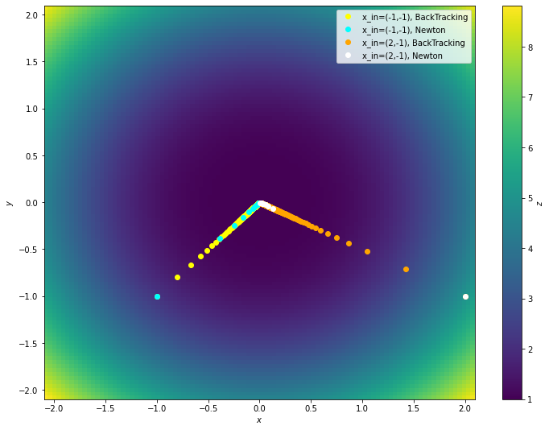

```python
plotProcess(f1, df_list=[(log_f1_1_back, "x_in=(-1,-1), BackTracking"), \
                                    (log_f1_1_newton, "x_in=(-1,-1), Newton"), \
                                    (log_f1_2_back, "x_in=(2,-1), BackTracking"), \
                                    (log_f1_2_newton, "x_in=(2,-1), Newton")], \
                     x_min=-2.1, x_max=2.1, y_min=-2.1, y_max=2.1)
```

[output not shown]

### $f_2$ の最小化

#### 初期値 $(-1,-1)^\text{T}$, 最急降下法

```python
log_f2_1_back, res_f2_1_back = BacktrackingMethod(f2, nabla_f2, [-1,-1])
```

```python
log_f2_1_back
```

|  | x_k | d_k | output | alpha |
| --- | --- | --- | --- | --- |
| 0 | [-1, -1] | [1.7999999999999998, 3.0] | 3.116667e+00 | 0.225180 |
| 1 | [-0.594676033536655, -0.32446005589442495] | [1.8942708036579101, 1.2435961453255049] | 8.815592e-01 | 0.144115 |
| 2 | [-0.32168284040089234, -0.14523896352043023] | [1.2956066240491253, 0.6121607674417529] | 2.637161e-01 | 0.092234 |
| 3 | [-0.20218422133070701, -0.08877709847561194] | [0.8631389296355099, 0.3797384182819309] | 1.058444e-01 | 0.092234 |
| 4 | [-0.12257370665549769, -0.05375241139060166] | [0.5363402462008586, 0.230078529436701] | 3.929013e-02 | 0.092234 |
| ... | ... | ... | ... | ... |
| 65 | [4.375000382534981e-07, -1.0562298128111938e-06] | [-6.937703402024468e-07, 1.6749595873688895e-06] | 1.036333e-12 | 0.073787 |
| 66 | [3.8630882260691826e-07, -9.326396094431934e-07] | [-6.125956809842375e-07, 1.4789703962794687e-06] | 8.079987e-13 | 0.073787 |
| 67 | [3.41107239615814e-07, -8.235108558721527e-07] | [-5.409181025909366e-07, 1.3059144721284913e-06] | 6.299729e-13 | 0.073787 |
| 68 | [3.0119452840248764e-07, -7.271513756741214e-07] | [-4.776267379357143e-07, 1.1531082229457553e-06] | 4.911714e-13 | 0.073787 |
| 69 | [2.659518956126441e-07, -6.420670065622398e-07] | [-4.2174057588825765e-07, 1.0181821175118356e-06] | 3.829519e-13 | 0.073787 |

70 rows × 4 columns

$(x,y)\simeq(0,0)$に70回程度で収束し,そこでの$f_2$の値はほぼ$0$である.

先に解析的に求めた大域的最適解に近い値となっている.

#### 初期値 $(2,-1)^\text{T}$, 最急降下法

```python
log_f2_2_back, res_f2_2_back = BacktrackingMethod(f2, nabla_f2, [2,-1])
```

```python
log_f2_2_back
```

|  | x_k | d_k | output | alpha |
| --- | --- | --- | --- | --- |
| 0 | [2, -1] | [-5.399999999999999, -0.0] | 0.866667 | 0.012379 |
| 1 | [1.9331512378785893, -1.0] | [-3.388273273829906, 0.06684876212141067] | 0.575478 | 0.012379 |
| 2 | [1.8912064463814433, -0.9991724524079324] | [-2.349265560014744, 0.10713845843442149] | 0.455639 | 0.012379 |
| 3 | [1.8621239473848787, -0.9978461425334996] | [-1.720988062165227, 0.1335683376821204] | 0.396467 | 0.012379 |
| 4 | [1.8408191470920139, -0.9961926466015247] | [-1.3058050054758612, 0.15156614611103558] | 0.364054 | 0.012379 |
| ... | ... | ... | ... | ... |
| 520 | [1.747552403124588, -0.873776760218739] | [-1.0899923807983214e-07, 1.1173128899866214e-06] | 0.298638 | 0.012379 |
| 521 | [1.7475524017752426, -0.8737767463870754] | [-1.0643218106842767e-07, 1.0909989081042681e-06] | 0.298638 | 0.012379 |
| 522 | [1.7475524004576761, -0.8737767328811631] | [-1.0392558646987737e-07, 1.0653046500497254e-06] | 0.298638 | 0.012379 |
| 523 | [1.7475523991711397, -0.8737767196933303] | [-1.0147802409488094e-07, 1.0402155208311115e-06] | 0.298638 | 0.012379 |
| 524 | [1.7475523979149026, -0.8737767068160859] | [-9.908810316705541e-08, 1.015717269181593e-06] | 0.298638 | 0.012379 |

525 rows × 4 columns

$(x,y)\simeq(1.747552, -0.873777)$に500回程度で収束し,そこでの$f_2$の値は$0.298638$である.

先に解析的に求めた極小点の一つ(大域的最適解ではない)に近い値となっている.

#### 初期値 $(-1,-1)^\text{T}$, ニュートン法

```python
log_f2_1_newton, res_f2_1_newton = NewtonsMethod(f2, nabla_f2, nabla2_f2, [-1,-1])
```

```python
log_f2_1_newton
```

|  | x_k | d_k | output |
| --- | --- | --- | --- |
| 0 | [-1, -1] | [-0.07317073170731703, 1.5365853658536586] | 3.116667 |
| 1 | [-1.0731707317073171, 0.5365853658536586] | [0.0026265760130285737, -0.0013132880065142866] | 0.877346 |
| 2 | [-1.0705441556942885, 0.5352720778471443] | [1.8638696597545387e-06, -9.319348298772693e-07] | 0.877362 |

先に解析的に求めた鞍点に近い値となっている.

#### 初期値 $(2,-1)^\text{T}$, ニュートン法

```python
log_f2_2_newton, res_f2_2_newton = NewtonsMethod(f2, nabla_f2, nabla2_f2, [2,-1])
```

```python
log_f2_2_newton
```

|  | x_k | d_k | output |
| --- | --- | --- | --- |
| 0 | [2, -1] | [-0.16314199395770387, 0.08157099697885194] | 0.866667 |
| 1 | [1.836858006042296, -0.918429003021148] | [-0.07315402714679355, 0.03657701357339677] | 0.352980 |
| 2 | [1.7637039788955025, -0.8818519894477512] | [-0.015489341605918965, 0.007744670802959482] | 0.300203 |
| 3 | [1.7482146372895835, -0.8741073186447917] | [-0.000661114308194772, 0.000330557154097386] | 0.298641 |
| 4 | [1.7475535229813888, -0.8737767614906944] | [-1.1771473718739151e-06, 5.885736859369576e-07] | 0.298638 |

$(x,y)\simeq(1.747552, -0.873776)$にわずか5回で収束し,そこでの$f_2$の値は$0.298638$である.

先に解析的に求めた極小点の一つ(大域的最適解ではない)に近い値となっている.

#### 結果のまとめ

以上の結果をプロットしてみる.

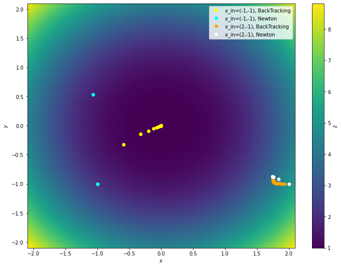

```python
plotProcess(f1, df_list=[(log_f2_1_back, "x_in=(-1,-1), BackTracking"), \
                                    (log_f2_1_newton, "x_in=(-1,-1), Newton"), \
                                    (log_f2_2_back, "x_in=(2,-1), BackTracking"), \
                                    (log_f2_2_newton, "x_in=(2,-1), Newton")], \
                     x_min=-2.1, x_max=2.1, y_min=-2.1, y_max=2.1)
```

[output not shown]

### 考察

冒頭の解析の通り,凸である$f_1$ではどちらの初期点からどちらの手法で始めても大域的最適解(原点)に収束した(収束する過程が見られ),

収束の速さを見ると,どちらの初期点から始めてもニュートン法は最急降下法よりもはるかに早く収束している.